# Assignment3

Aijing

9/20/2020

In this assignment, I will explore the relationship between median income, average travel time to workplace, percentage of labour force public transportation for commuting, majority race and nativity on the census tract level in Massachusetts state.

```r
library(tidycensus)
library(tidyverse)
library(ggplot2)
```

```r
tract_data <- read_csv("tracts2018_ma.csv")
attach(tract_data)
```

# Relationships between continuous variables with Pearson’s correlation

The three continuous variables studied here are:

1.Median income (continuous) : ‘med_income’

2.Percentage of of labour force using public transportation to workplace(continuous): ‘pct_publictrans’

3.Avg. Travel time to workplace for labor force (continuous): ‘avg_travel_time’

```r
correlation1 <- cor.test(tract_data$med_incomeE, tract_data$pct_publictrans)
correlation1
```

```
##
##  Pearson's product-moment correlation
##
## data:  tract_data$med_incomeE and tract_data$pct_publictrans
## t = 3.1919, df = 1457, p-value = 0.001444
## alternative hypothesis: true correlation is not equal to 0
## 95 percent confidence interval:
##  0.03214811 0.13407702
## sample estimates:
##        cor
## 0.08333051
```

```r
correlation2 <- cor.test(tract_data$med_incomeE, tract_data$avg_travel_time)
correlation2
```

```
##
##  Pearson's product-moment correlation
##
## data:  tract_data$med_incomeE and tract_data$avg_travel_time
## t = 17.423, df = 1457, p-value < 2.2e-16
## alternative hypothesis: true correlation is not equal to 0
## 95 percent confidence interval:
##  0.3718384 0.4568196
## sample estimates:
##       cor
## 0.4152345
```

```r
correlation3 <- cor.test(tract_data$pct_publictrans, tract_data$avg_travel_time)
correlation3
```

```
##
##  Pearson's product-moment correlation
##
## data:  tract_data$pct_publictrans and tract_data$avg_travel_time
## t = 12.428, df = 1457, p-value < 2.2e-16
## alternative hypothesis: true correlation is not equal to 0
## 95 percent confidence interval:
##  0.2624499 0.3552749
## sample estimates:
##       cor
## 0.3095998
```

I have the following observations: 1.Median Income and Percentage of of labour force using public transportation to workplace have a very weak but statistically significant, positive correlation at a 95% confidence level. 2.Median Income and average travel time to workplace have weak but a statistically significant positive correlation at a 95% confidence level. 3.Percentage of of labour force using public transportation to workplace and average travel time to workplace have a weak but statistically significant, positive correlation at a 95% confidence level.

I will visualize the correlation between median Income and Percentage of of labour force using public transportation using a scatterplot.

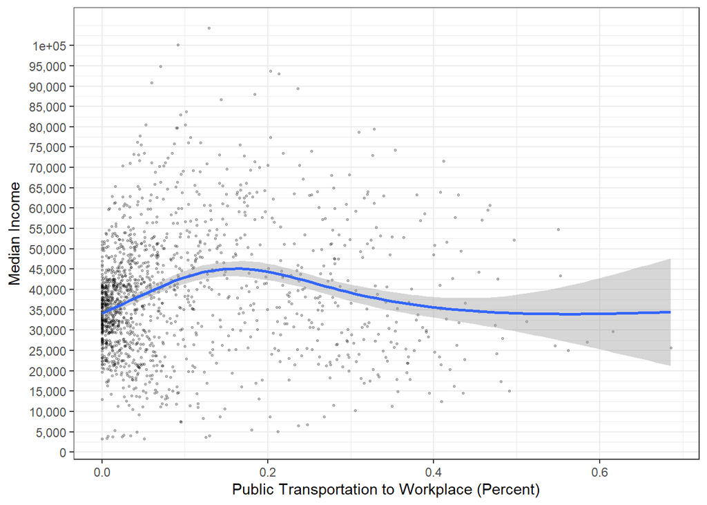

```r
ggplot(tract_data, aes(x = pct_publictrans, y = med_incomeE)) +
    geom_point(size = 0.5, alpha = 0.25, position = "jitter") +
    geom_smooth() +
    theme_bw() +
    scale_x_continuous(name = "Public Transportation to Workplace (Percent)") +
    scale_y_continuous(name = "Median Income",
                      breaks = seq(0, 100000, by = 5000),
                      labels = paste("",
                                  prettyNum(seq(0, 100000, by = 5000),
                                            big.mark = ",")))
```

# Relationship between two categorical variables with Chi-Square Test

Below I will use the chi-square test of association to determine whether there is a statistically significant association between the two categorical variables:

1.Majority race of the population (categorical) : ‘maj_race’

2.Whether the majority of the population is foreign born or not(categorical): ‘maj_foreign’

Because I have do not have enough observations for every category, I decide to mutate my majority race categoryinto hispanic and non-hispanic.

```r
tract_data_modified <- tract_data %>%
  mutate(maj_race = case_when(maj_race == 'asian' ~ "non_hispanic",
                              maj_race == 'no_majority' ~ "non_hispanic",
                              maj_race == 'white' ~ "non_hispanic",
                              maj_race == 'hs_latino' ~ "hs_latino",
                              maj_race == 'black' ~ "non_hispanic",))
```

```r
chi_sq <- chisq.test(tract_data_modified$maj_race, tract_data_modified$maj_foreign == "TRUE")
chi_sq
```

```
##
##  Pearson's Chi-squared test with Yates' continuity correction
##
## data:  tract_data_modified$maj_race and tract_data_modified$maj_foreign == "TRUE"
## X-squared = 99.542, df = 1, p-value < 2.2e-16
```

```r
chi_sq$observed
```

```
##
## tract_data_modified$maj_race FALSE TRUE
##                 hs_latino       55   12
##                 non_hispanic  1379   13
```

```r
chi_sq$expected
```

```
##
## tract_data_modified$maj_race      FALSE      TRUE
##                 hs_latino      65.85195  1.148047
##                 non_hispanic 1368.14805 23.851953
```

There is a statistically significant relationship between race and nativity at a 95% confidence level.

# Relationships between race and continuous variables with ANOVA

I use the anova test to find the relationship between race and my continuous variables: median income, average travel time to workplace, percentage of labour force public transportation for commuting.

```r
anova <- aov (med_incomeE ~ maj_race, data = tract_data)
summary(anova)
```

```
##               Df    Sum Sq   Mean Sq F value Pr(>F)
## maj_race       4 6.513e+10 1.628e+10   91.83 <2e-16 ***
## Residuals   1454 2.578e+11 1.773e+08
## ---
## Signif. codes:  0 '***' 0.001 '**' 0.01 '*' 0.05 '.' 0.1 ' ' 1
```

```r
anova <- aov (pct_publictrans ~ maj_race, data = tract_data)
summary(anova)
```

```
##               Df Sum Sq Mean Sq F value Pr(>F)
## maj_race       4  2.705  0.6763   57.49 <2e-16 ***
## Residuals   1454 17.105  0.0118
## ---
## Signif. codes:  0 '***' 0.001 '**' 0.01 '*' 0.05 '.' 0.1 ' ' 1
```

```r
anova <- aov (avg_travel_time ~ maj_race, data = tract_data)
summary(anova)
```

```
##               Df Sum Sq Mean Sq F value   Pr(>F)
## maj_race       4   1641   410.2   14.11 2.65e-11 ***
## Residuals   1454  42263    29.1
## ---
## Signif. codes:  0 '***' 0.001 '**' 0.01 '*' 0.05 '.' 0.1 ' ' 1
```

```r
differences <- TukeyHSD(anova)
as_tibble(cbind(pair = row.names(differences$maj_race),
                differences$maj_race))
```

```
## # A tibble: 10 x 5
##    pair              diff          lwr            upr           `p adj`
##    <chr>             <chr>         <chr>          <chr>         <chr>
##  1 black-asian       4.7062961780~ -1.8000311206~ 11.212623476~ 0.2784607474653~
##  2 hs_latino-asian   -3.286203317~ -9.5610342537~ 2.9886276193~ 0.6080731788011~
##  3 no_majority-asian 0.2151630731~ -5.9072594487~ 6.3375855949~ 0.9999808263938~
##  4 white-asian       0.7110394033~ -5.3155292662~ 6.7376080730~ 0.9976693847468~
##  5 hs_latino-black   -7.992499495~ -11.063516971~ -4.921482018~ 1.6904921906757~
##  6 no_majority-black -4.491133104~ -7.2373491550~ -1.744917054~ 8.3708010802041~
##  7 white-black       -3.995256774~ -6.5205636842~ -1.469949865~ 0.0001612025280~
##  8 no_majority-hs_l~ 3.5013663903~ 1.36059294177~ 5.6421398388~ 8.3528588097792~
##  9 white-hs_latino   3.9972427205~ 2.14835566301~ 5.8461297781~ 4.3811371419622~
## 10 white-no_majority 0.4958763302~ -0.7406258354~ 1.7323784959~ 0.8090389894176~
```

There exists a significant association between race and median income, race and percentage of labour force public transportation for commuting, and race and average travel time to workplace at a 95% confidence level. All p-values fall well below the 0.05 threshold.

I chose to display the relationship between percentage of labour force public transportation for commuting and majority race using a box-plot.

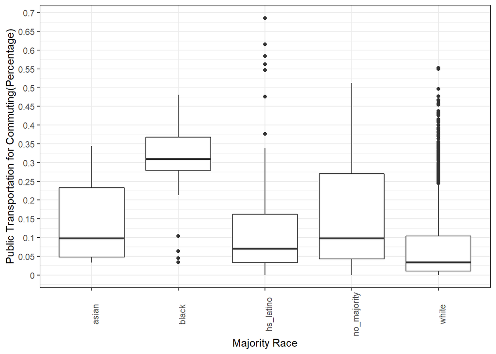

```r
ggplot(tract_data, aes(x = maj_race, y = pct_publictrans)) +
  geom_boxplot() +
  theme_bw() +
  theme(axis.text.x = element_text(angle = 90)) +
  scale_x_discrete(name = "Majority Race") +
    scale_y_continuous(name = "Public Transportation for Commuting(Percentage)",
                     breaks = seq(0, 1, by = 0.05),
                     labels = paste(prettyNum(seq(0, 1, by = 0.05))))
```

# Relationships between nativity and continuous variables with Two-sample T-test

```r
difference1 = t.test(med_incomeE ~ maj_foreign == "TRUE",
                    data = tract_data)
difference1
```

```
##
##  Welch Two Sample t-test
##
## data:  med_incomeE by maj_foreign == "TRUE"
## t = 13.642, df = 31.751, p-value = 7.968e-15
## alternative hypothesis: true difference in means is not equal to 0
## 95 percent confidence interval:
##  12602.84 17028.65
## sample estimates:
## mean in group FALSE  mean in group TRUE
##            38566.82            23751.08
```

```r
difference2 = t.test(pct_publictrans ~ maj_foreign == "TRUE",
                    data = tract_data)
difference2
```

```
##
##  Welch Two Sample t-test
##
## data:  pct_publictrans by maj_foreign == "TRUE"
## t = -4.4252, df = 24.258, p-value = 0.0001754
## alternative hypothesis: true difference in means is not equal to 0
## 95 percent confidence interval:
##  -0.26300500 -0.09576958
## sample estimates:
## mean in group FALSE  mean in group TRUE
##          0.09141503          0.27080231
```

```r
difference3 = t.test(avg_travel_time ~ maj_foreign == "TRUE",
                    data = tract_data)
difference3
```

```
##
##  Welch Two Sample t-test
##
## data:  avg_travel_time by maj_foreign == "TRUE"
## t = -1.7225, df = 24.831, p-value = 0.09742
## alternative hypothesis: true difference in means is not equal to 0
## 95 percent confidence interval:
##  -4.2169738  0.3765583
## sample estimates:
## mean in group FALSE  mean in group TRUE
##            25.43024            27.35044
```

There is a statistically significant relationship found between median income and nativity at a 95% confidence level; tracts with a majority foreign born population have a much lower median income.

There is no significant relationship found between nativity and average travel time at a 95% confidence level.